# Rasterize national caloric data

last run by: jvillasenor

2020-04-09

# Load packages

```r
suppressPackageStartupMessages({
  library(here)
  library(startR)
  library(cowplot)
  library(stargazer)
  library(tidyverse)
})

source(here("code", "file_names.R"))
```

# Load data

```r
protein_gdp <- read.csv(protein_gdp_fn, stringsAsFactors = F) %>%
  select(ISO3, protein_g_cap_year, pc_gdp = NY.GDP.PCAP.CD) %>%
  mutate(log_pc_gdp = log10(pc_gdp)) %>%
  mutate(name = countrycode::countrycode(ISO3, "iso3c", "country.name"),
         region = countrycode::countrycode(ISO3, "iso3c", "region"))
```

# Identify missing values

The first step is to identify which values are missing. Our target is the `world_vector_sf` file (already contained in these data), which has all the political boundaries we care about. The table below shows the countries for which we don’t have annual per capita protein consumption but do have gdp (we can model this), as well as the ones for which we have none of them.

```r
protein_gdp %>%
  filter(is.na(protein_g_cap_year)) %>%
  mutate(id = rownames(.)) %>%
  knitr::kable()
```

| ISO3 | protein_g_cap_year | pc_gdp | log_pc_gdp | name | region | id |
| --- | --- | --- | --- | --- | --- | --- |
| ABW | NA | 25025.0996 | 4.398376 | Aruba | Caribbean | 1 |
| AIA | NA | NA | NA | Anguilla | Caribbean | 2 |
| ALA | NA | NA | NA | Åland Islands | Northern Europe | 3 |
| AND | NA | 40626.7516 | 4.608812 | Andorra | Southern Europe | 4 |
| ASM | NA | 11505.3937 | 4.060901 | American Samoa | Polynesia | 5 |
| ATA | NA | NA | NA | Antarctica | NA | 6 |
| ATF | NA | NA | NA | French Southern Territories | NA | 7 |
| BDI | NA | 256.9760 | 2.409893 | Burundi | Eastern Africa | 8 |
| BES | NA | NA | NA | Caribbean Netherlands | Caribbean | 9 |
| BHR | NA | 24744.3576 | 4.393476 | Bahrain | Western Asia | 10 |
| BLM | NA | NA | NA | St. Barthélemy | Caribbean | 11 |
| BTN | NA | 2532.0156 | 3.403466 | Bhutan | Southern Asia | 12 |
| BVT | NA | NA | NA | Bouvet Island | NA | 13 |
| CCK | NA | NA | NA | Cocos (Keeling) Islands | NA | 14 |
| COD | NA | 457.9637 | 2.660831 | Congo - Kinshasa | Middle Africa | 15 |
| COK | NA | NA | NA | Cook Islands | Polynesia | 16 |
| COM | NA | 1504.9209 | 3.177514 | Comoros | Eastern Africa | 17 |
| CPT | NA | NA | NA | NA | NA | 18 |
| CUW | NA | 20462.7180 | 4.310963 | Curaçao | Caribbean | 19 |
| CXR | NA | NA | NA | Christmas Island | NA | 20 |
| CYM | NA | 73515.8953 | 4.866381 | Cayman Islands | Caribbean | 21 |
| ERI | NA | NA | NA | Eritrea | Eastern Africa | 22 |
| ESH | NA | NA | NA | Western Sahara | Northern Africa | 23 |
| ETH | NA | 499.5316 | 2.698563 | Ethiopia | Eastern Africa | 24 |
| FLK | NA | NA | NA | Falkland Islands | South America | 25 |
| FRO | NA | 54853.6256 | 4.739205 | Faroe Islands | Northern Europe | 26 |
| GGY | NA | NA | NA | Guernsey | Northern Europe | 27 |
| GIB | NA | NA | NA | Gibraltar | Southern Europe | 28 |
| GLP | NA | NA | NA | Guadeloupe | Caribbean | 29 |
| GNQ | NA | 20384.9245 | 4.309309 | Equatorial Guinea | Middle Africa | 30 |

[output cut: 57 more lines]

# Impute missing values

The table above shows that there are 87 locations for which we dont have protein consumption data. At the same time, there are 51 locations for which we don’t have GDP. For the cases where we have GDP data, we’ll use the relationship between GDP and protein consumption (this is well-established). For the ones where we don’t have GDP data, we’ll calculate the median for each geopolitical region, and use this value in the corresponding location.

From previous work, we know that as people’s income increases, so does their protein consumption (Tilman’s work, for example). Let’s look at the relationship between per-capita GDP and protein consumption in our dataset.

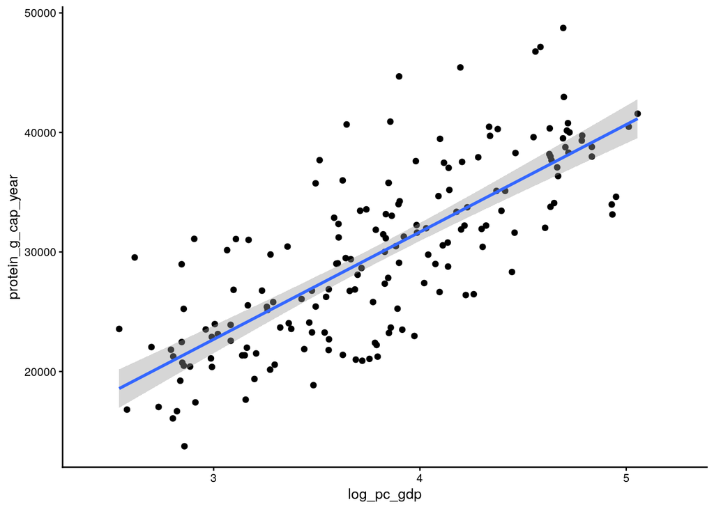

```r
ggplot(data = protein_gdp,
       mapping = aes(x = log_pc_gdp, y = protein_g_cap_year)) +
  geom_point() +
  ggtheme_plot() +
  geom_smooth(method = "lm")
```

## Modeled

The figure above clearly shows the known relationship. Let’s do a quick balance check to see where along the GDP range our missing values lie.

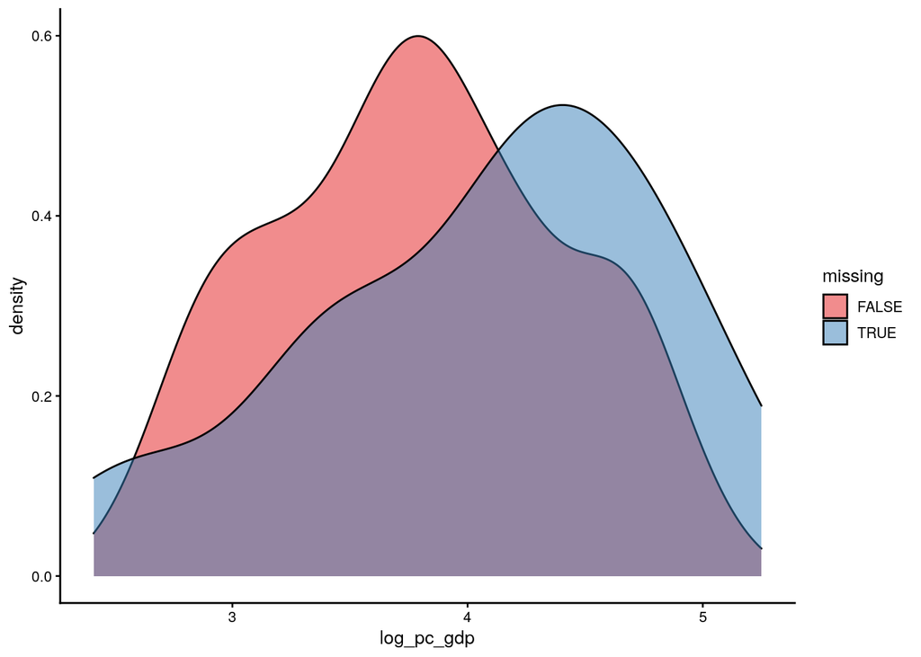

```r
protein_gdp %>%
  mutate(missing = is.na(protein_g_cap_year)) %>%
  ggplot(aes(x = log_pc_gdp, fill = missing)) +
  geom_density(alpha = 0.5) +
  scale_fill_brewer(palette = "Set1")+
  ggtheme_plot()
```

```r
prot_gdp_model <- lm(protein_g_cap_year ~ log_pc_gdp, data = protein_gdp)

stargazer(prot_gdp_model,
          type = "html",
          out = here("results", "tab", "supp_protein_intake_imputation_model.html"),
          single.row = T)
```

|  | *Dependent variable:* |
| --- | --- |
|  | protein_g_cap_year |
| log_pc_gdp | 8,983.259*** (584.407) |
| Constant | -4,261.140* (2,245.397) |
| Observations | 174 |
| R<sup>2</sup> | 0.579 |
| Adjusted R<sup>2</sup> | 0.576 |
| Residual Std. Error | 4,760.402 (df = 172) |
| F Statistic | 236.285*** (df = 1; 172) |
| *Note:* | p<0.1; p<0.05; p<0.01 |

```r
national_prot_imputed <- protein_gdp %>%
  mutate(protein_g_cap_year_imputed_m = predict(prot_gdp_model, newdata = .),
         imputed_m = is.na(protein_g_cap_year))
```

### Check predictions

First, a fitted vs predicted plot

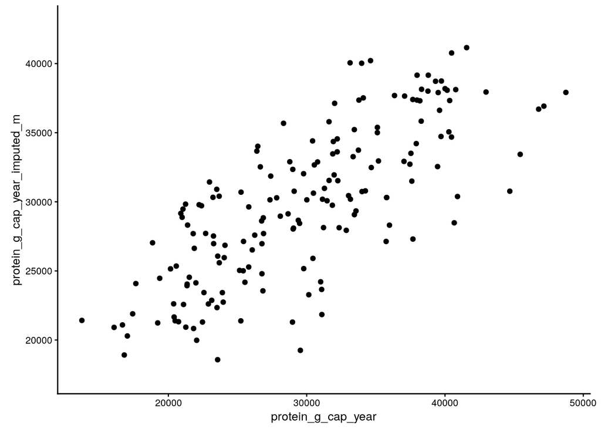

```r
ggplot(data = national_prot_imputed,
       mapping = aes(x = protein_g_cap_year, y = protein_g_cap_year_imputed_m)) +
  geom_point() +
  ggtheme_plot() +
  coord_equal()
```

Now, one where we see the predicted values in context

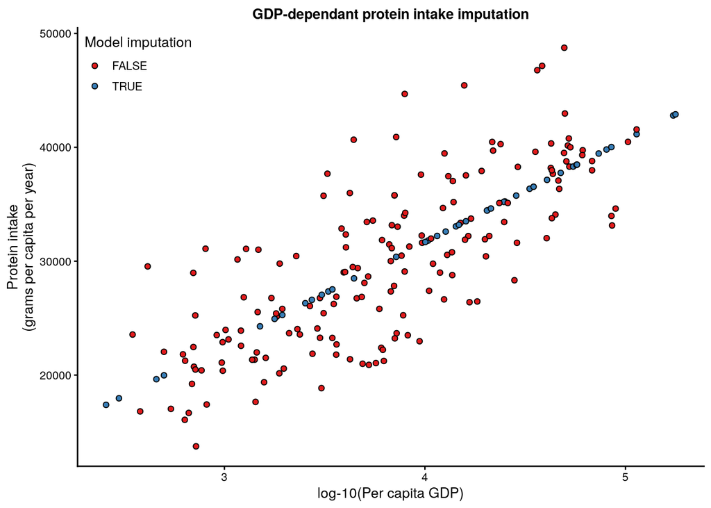

```r
plot1 <- national_prot_imputed %>%
  mutate(protein_g_cap_year = ifelse(is.na(protein_g_cap_year), protein_g_cap_year_imputed_m, protein_g_cap_year)) %>%
  ggplot(mapping = aes(x = log_pc_gdp, y = protein_g_cap_year, fill = imputed_m)) +
  geom_point(color = "black", shape = 21) +
  scale_fill_brewer(name = "Model imputation", palette = "Set1") +
  ggtheme_plot() +
  labs(x = "log-10(Per capita GDP)", y = "Protein intake\n(grams per capita per year)") +
  ggtitle(label =  "GDP-dependant protein intake imputation") +
  theme(legend.justification = c(0, 1),
        legend.position = c(0, 1))


plot1
```

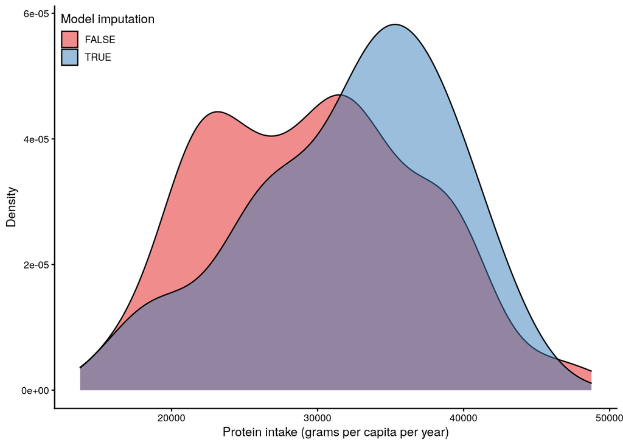

```r
plot2 <- national_prot_imputed %>%
  mutate(protein_g_cap_year = ifelse(is.na(protein_g_cap_year), protein_g_cap_year_imputed_m, protein_g_cap_year)) %>%
  ggplot(mapping = aes(x = protein_g_cap_year, fill = imputed_m)) +
  geom_density(alpha = 0.5) +
  scale_fill_brewer(name = "Model imputation", palette = "Set1") +
  ggtheme_plot() +
  labs(x = "Protein intake (grams per capita per year)", y = "Density") +
  theme(legend.justification = c(0, 1),
        legend.position = c(0, 1))

plot2
```

## Geopolitical regions

There are still 51 points for which we don’t have protein consumption data. Since we don’t have GDP information for these, we’ll instead impute them using geopolitical medians.

```r
# Start imputation
national_prot_imputed <- national_prot_imputed %>%
  mutate(region = countrycode::countrycode(sourcevar = ISO3,
                                           origin = "iso3c",
                                           destination = "region")) %>%
  mutate(region = case_when(ISO3 == "ATF" ~ "Eastern Africa",
                            ISO3 == "CCK" ~ "South-Eastern Asia",
                            ISO3 == "CXR" ~ "South-Eastern Asia",
                            ISO3 == "IOT" ~ "Southern Asia",
                            T ~ region)) %>%
  select(ISO3, name, log_pc_gdp, region, contains("_year"), imputed_m) %>%
  group_by(region) %>%
  mutate(protein_g_cap_year_imputed_r = median(protein_g_cap_year, na.rm = T)) %>%
  ungroup() %>%
  mutate(imputed_r = is.na(protein_g_cap_year_imputed_m),
         protein_g_cap_year = ifelse(imputed_m, protein_g_cap_year_imputed_m, protein_g_cap_year),
         protein_g_cap_year = ifelse(imputed_r, protein_g_cap_year_imputed_r, protein_g_cap_year)) %>%
  select(-contains("_median"))
```

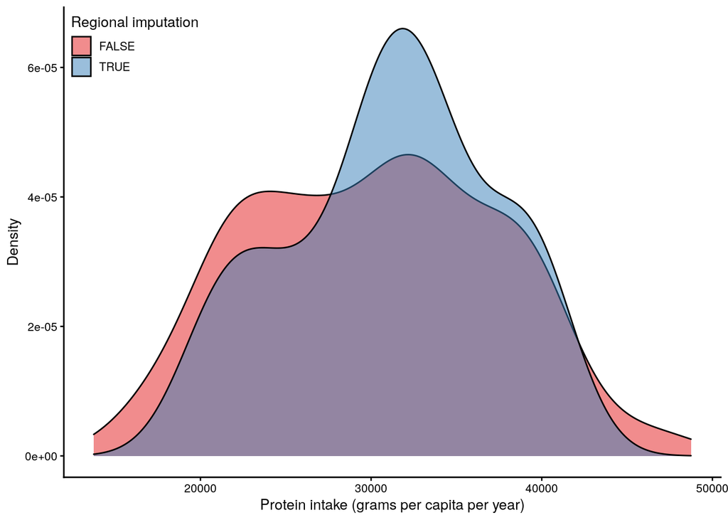

```r
plot3 <- national_prot_imputed %>%
  ggplot(mapping = aes(x = protein_g_cap_year, fill = imputed_r)) +
  geom_density(alpha = 0.5) +
  scale_fill_brewer(name = "Regional imputation", palette = "Set1") +
  ggtheme_plot() +
  labs(x = "Protein intake (grams per capita per year)", y = "Density") +
  theme(legend.justification = c(0, 1),
        legend.position = c(0, 1))

plot3
```

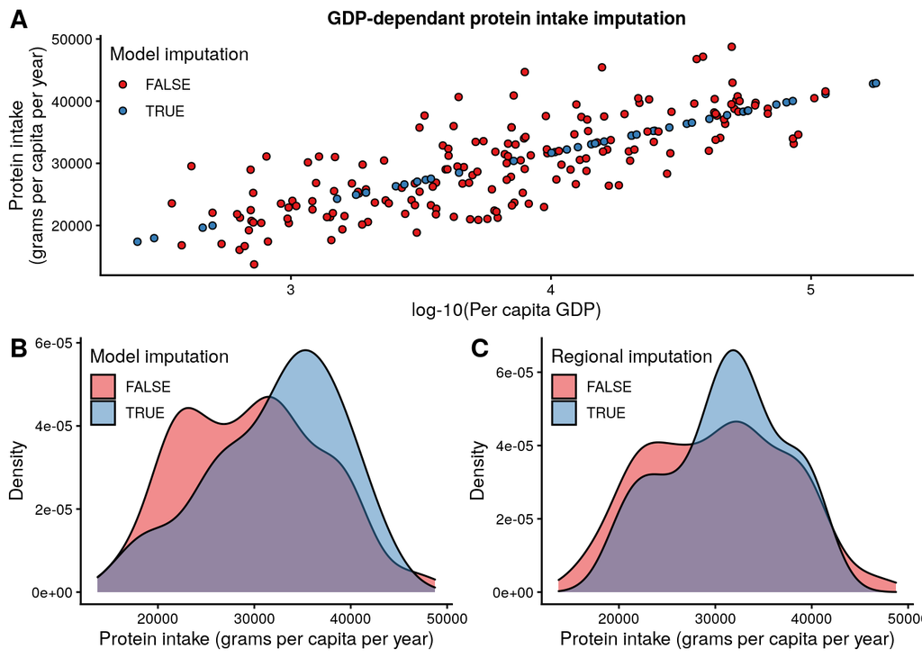

```r
p <- plot_grid(plot1,
               plot_grid(plot2, plot3, ncol = 2, labels = c("B", "C")),
               ncol = 1, labels = c("A", NA))
p
```

```r
lazy_ggsave(plot = p, filename = "supp_protein_intake_imputation", width = 18, 10)
national_prot_imputed %>%
  filter(imputed_m) %>%
  mutate_at(vars(protein_g_cap_year), replace_na, 0) %>%
  mutate(imputed_from = ifelse(imputed_r, "Geopolitical regional median", "GDP model")) %>%
  select(ISO3, Region = region, `Source of Imputation` = imputed_from, `Protein consumption (per capita annual grams)` = protein_g_cap_year) %T>%
  write.csv(here("results", "tab", "supp_protein_intake_imputation_sources.csv")) %>%
  knitr::kable(caption = "Imputed countries, with source of inputation.")
```

Imputed countries, with source of inputation.

| ISO3 | Region | Source of Imputation | Protein consumption (per capita annual grams) |
| --- | --- | --- | --- |
| ABW | Caribbean | GDP model | 35250.61 |
| AIA | Caribbean | Geopolitical regional median | 30426.40 |
| ALA | Northern Europe | Geopolitical regional median | 39949.25 |
| AND | Southern Europe | GDP model | 37141.02 |
| ASM | Polynesia | GDP model | 32218.99 |
| ATA | NA | Geopolitical regional median | 0.00 |
| ATF | Eastern Africa | Geopolitical regional median | 20916.33 |
| BDI | Eastern Africa | GDP model | 17387.55 |
| BES | Caribbean | Geopolitical regional median | 30426.40 |
| BHR | Western Asia | GDP model | 35206.60 |
| BLM | Caribbean | Geopolitical regional median | 30426.40 |
| BTN | Southern Asia | GDP model | 26313.08 |
| BVT | NA | Geopolitical regional median | 0.00 |
| CCK | South-Eastern Asia | Geopolitical regional median | 24557.20 |
| COD | Middle Africa | GDP model | 19641.80 |
| COK | Polynesia | Geopolitical regional median | 33284.35 |
| COM | Eastern Africa | GDP model | 24283.29 |
| CPT | NA | Geopolitical regional median | 0.00 |
| CUW | Caribbean | GDP model | 34465.36 |
| CXR | South-Eastern Asia | Geopolitical regional median | 24557.20 |
| CYM | Caribbean | GDP model | 39454.83 |
| ERI | Eastern Africa | Geopolitical regional median | 20916.33 |
| ESH | Northern Africa | Geopolitical regional median | 35744.45 |
| ETH | Eastern Africa | GDP model | 19980.75 |
| FLK | South America | Geopolitical regional median | 26997.22 |
| FRO | Northern Europe | GDP model | 38312.37 |
| GGY | Northern Europe | Geopolitical regional median | 39949.25 |
| GIB | Southern Europe | Geopolitical regional median | 38943.68 |
| GLP | Caribbean | Geopolitical regional median | 30426.40 |
| GNQ | Middle Africa | GDP model | 34450.50 |

[output cut: 57 more lines]

```r
file.remove(protein_gdp_imputed_fn)
```

```
## [1] TRUE
```

```r
write.csv(x = national_prot_imputed,
          file = protein_gdp_imputed_fn,
          row.names = F)
```